# DS_HA

Devang

1/3/2022

## In this assignment we will do exploratory data analysis and hypothesis testing on covid19 dataset that we have got.

### In this dataset there are 20 variables with all the variables indicating some kind of trend in COVID cases.

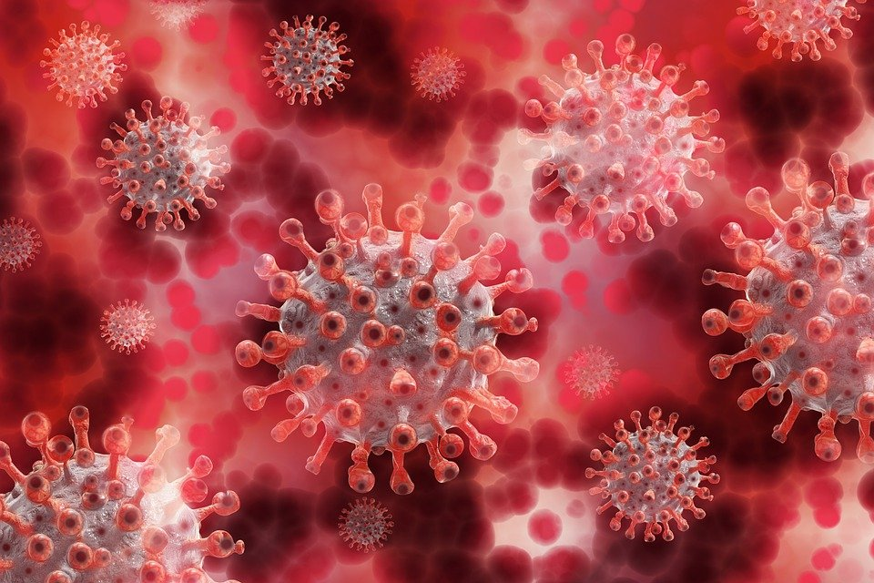

## Variable Description

### Legend : FIPS - Federal Information Processing Series

- Date as of : Date when the data was added in dataset
- Start week: Start data of survey
- End week: End data of survey
- State: State of subject
- County Name: County of subject
- Urban rural code: Rural-Urban Continuum Codes form a classification scheme that distinguishes metropolitan (metro) counties by the population size of their metro area, and nonmetropolitan (nonmetro) counties by degree of urbanization and adjacency to a metro area or areas
- FIPS State: FIPS state codes were numeric and two-letter alphabetic codes defined in U.S. Federal Information Processing Standard Publication (“FIPS PUB”) 5-2 to identify U.S. states and certain other associated areas. … The codes are used in Geographic Names Information System, overseen by the U.S. Board on Geographic Names.
- FIPS County: The Federal Information Processing Standard Publication 6-4 (FIPS 6-4) is a five-digit Federal Information Processing Standards code which uniquely identified counties and county equivalents in the United States, certain U.S. possessions, and certain freely associated states.
- FIPS Code: FIPS codes are numbers which uniquely identify geographic areas. The number of digits in FIPS codes vary depending on the level of geography
- Indicator: There are three survey patterns that are conducted for constructing this dataset on each county : Distribution of all-cause deaths (%), Distribution of COVID-19 deaths (%), Distribution of population (%)
- Total Deaths: Total deaths in the span of the survey
- COVID-19 Deaths: Deaths due to COVID-19
- Non-Hispanic White: Non-Hispanic whites are European Americans, Middle Eastern Americans, and North African Americans as defined by the United States Census Bureau.
- Non-Hispanic Black: A person having origins in any of the black racial groups of Africa
- Non-Hispanic American Indian or Alaska Native: The term ‘Alaska Native’ are used in place of the word ‘Indian’ to include all indigenous people in Alaska.
- Non-Hispanic Asian:A person having origins in any of the original peoples of the Far East, Southeast Asia, or the Indian Subcontinent.
- Other: Groups not identified by any category
- Hispanic: A Spanish-speaking person, especially one of Latin American descent, living in the US.
- Urban Rural Description: The type and scale of urbanization of an area e.g. metro, small metro, etc.
- Footnote: An additional piece of information printed at the bottom of a page.

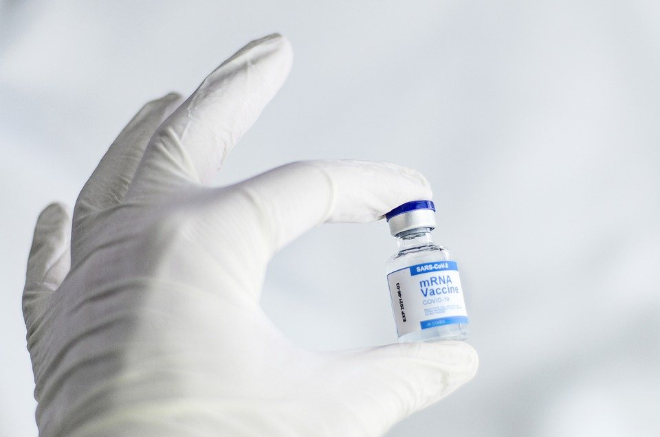

## Survey Description

### The survey conducted for building the dataset was done to infer the following:

- To show the trend of COVID-19 increase with time
- To monitor which counties have more spread of infection and which have less so as to prioritize the resources and medical response
- To establish a relation between urban/rural areas and COVID-19 infection
- To observe which groups of people among the vast variety of human population catches the infection more and why

## Metadata

The dataset was provided by teacher

1. Urban-Rural Description : For this variable there are no units as it is categorical data, for hypothesis testing we used mean/median.
2. COVID-19 Deaths: It is numerical data without units, for hypothesis testing we used mean/median.
3. Distribution of all-cause death(%): Unit here is percentage
4. Distribution of Covid-19 death(%): Unit here is percentage
5. There are some footnotes for some rows for all features
6. In many rows data based on counts less than 10 is suppressed

### Datatypes:

- Date as of : date, Quantitative
- Start week: date, Quantitative
- State: String, Qualitative
- County Name: String, Qualitative
- Urban rural code: Integer, Qualitative
- FIPS State: Integer, Qualitative
- FIPS County: Integer, Qualitative
- FIPS Code: Integer, Qualitative
- Indicator: String, Quantitative
- Total Deaths: Integer, Quantitative
- COVID-19 Deaths:Integer,Quantitative
- Non-Hispanic White: Float, Quantitative
- Non-Hispanic Black: Float, Quantitative
- Non-Hispanic American Indian or Alaska Native:Float, Quantitative
- Non-Hispanic Asian: Float, Quantitative
- Other: Float, Quantitative
- Hispanic: Float, Quantitative
- Urban Rural Description: String, Qualitative
- Footnote: String, Qualitative

## H₀ Null Hypothesis

### The null hypothesis urban areas project at least 700 COVID-19 deaths

## Hₐ Alternate Hypothesis

### The alternate hypothesis is that urban areas have no significant impact on rise in COVID-19 deaths

## R Code for hypothesis testing

```r
# Library Imports section

library(ggplot2)
```

```r
#Read Csv file
hp <- read.csv("covid.csv")
head(hp)
```

```
##   Data.as.of Start.week   End.Week State    County.Name Urban.Rural.Code
## 1 10/14/2020   2/1/2020 10/10/2020    AL  Etowah County                4
## 2 10/14/2020   2/1/2020 10/10/2020    AL  Etowah County                4
## 3 10/14/2020   2/1/2020 10/10/2020    AL  Etowah County                4
## 4 10/14/2020   2/1/2020 10/10/2020    AL Houston County                4
## 5 10/14/2020   2/1/2020 10/10/2020    AL Houston County                4
## 6 10/14/2020   2/1/2020 10/10/2020    AL Houston County                4
##   FIPS.State FIPS.County FIPS.Code                            Indicator
## 1          1          55      1055 Distribution of all-cause deaths (%)
## 2          1          55      1055  Distribution of COVID-19 deaths (%)
## 3          1          55      1055       Distribution of population (%)
## 4          1          69      1069 Distribution of all-cause deaths (%)
## 5          1          69      1069  Distribution of COVID-19 deaths (%)
## 6          1          69      1069       Distribution of population (%)
##   Total.deaths c19d Non.Hispanic.White Non.Hispanic.Black
```

[output cut: 20 more lines]

```r
urd <- hp$urd
c19d <- hp$c19d

df <- data.frame(urd,c19d)

head(df)
```

```
##           urd c19d
## 1 Small metro  129
## 2 Small metro  129
## 3 Small metro  129
## 4 Small metro  219
## 5 Small metro  219
## 6 Small metro  219
```

```r
mean_deaths <- mean(df$c19d)
mean_deaths
```

```
## [1] 541.0315
```

```r
standardDeviation <- sd(df$c19d)
standardDeviation
```

```
## [1] 829.8194
```

```r
n <- 5
```

```r
expected_deaths <- 700
```

```r
se <- standardDeviation/sqrt(n)

zScore <- (mean_deaths - expected_deaths)/se
zScore
```

```
## [1] -0.4283634
```

```r
p1<-pnorm(zScore,0,1)
p1
```

```
## [1] 0.3341933
```

```r
# if p1 < 0.05 reject null hypothesis
```

## Data Visualization

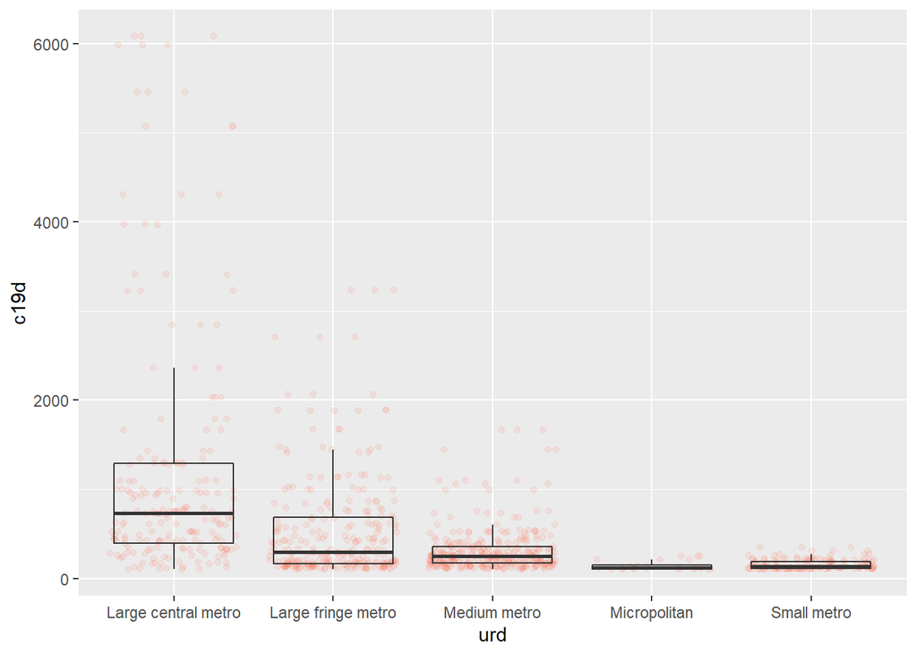

```r
# Box Plot for Urban Rural Description and COVID 19 Deaths

ggplot(data = df,aes(x = urd , y = c19d )) +
    geom_jitter(alpha = 0.1, color = "tomato") +
    geom_boxplot(alpha = 0)
```

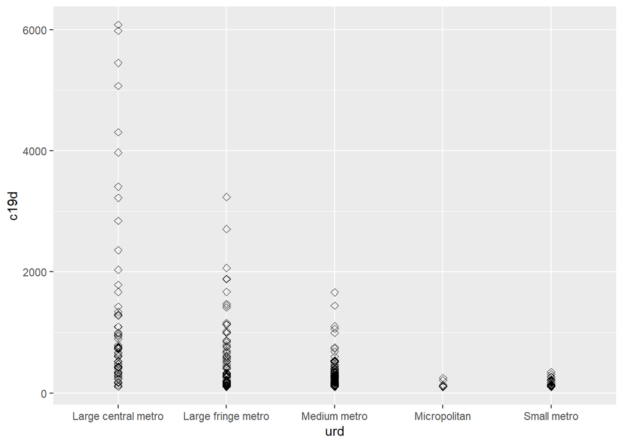

```r
# Scatter plots

ggplot(df, aes(x=urd, y=c19d)) +
  geom_point(size=2, shape=23)
```

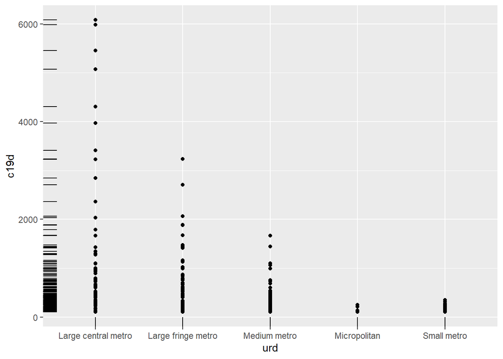

```r
# Add marginal rugs
ggplot(df, aes(x=urd, y=c19d), color="cyl") +
  geom_point() + geom_rug()
```

## Excel/CSV Data Analysis

### In this section we have included some data analysis pictures done in excel relating to this database

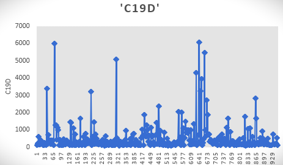

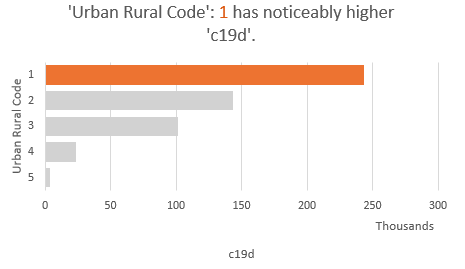

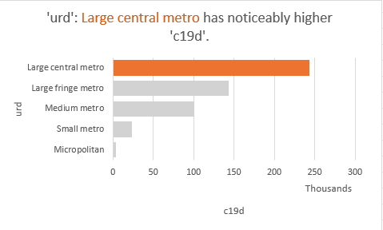

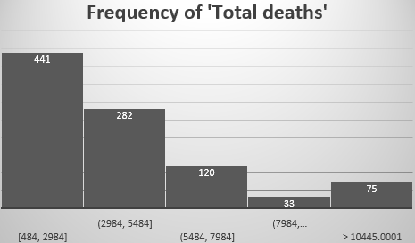